# 09 - Support Vector Machines

Biostatistics 735/794 — Machine Learning in Public Health

Alexander McLain

October 13, 2025

# Support Vector Machines on Simulated data

In this example we’re going to look at SVM’s with some simulated data.

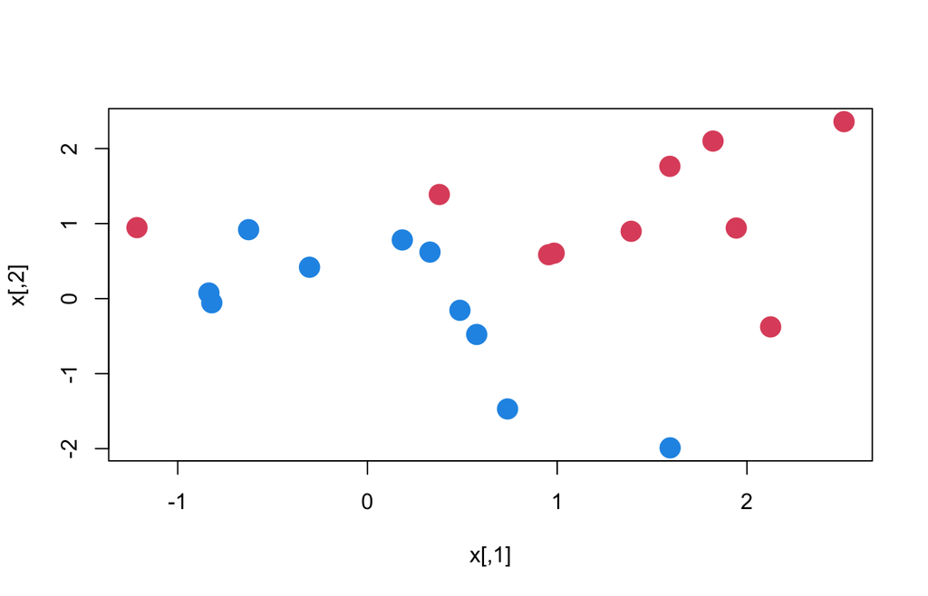

```r
set.seed(1)
x <- matrix(rnorm(20*2),20,2)
y <- c(rep(-1,10),rep(1,10))
x[y==1,] = x[y==1,] + 1

plot(x,col=(3-y), pch = 19, cex = 2)
```

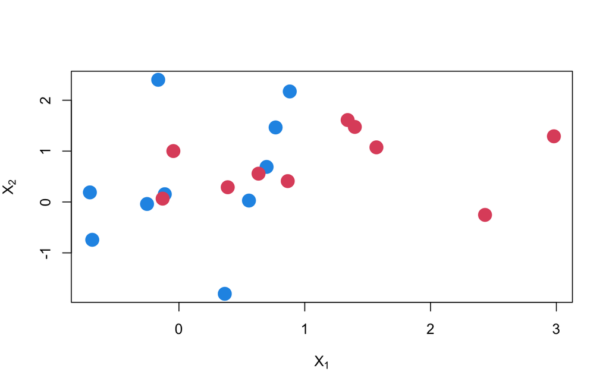

```r
dat <- data.frame(x=x,y=as.factor(y))

x <- matrix(rnorm(20*2),20,2)
y <- c(rep(-1,10),rep(1,10))
x[y==1,] = x[y==1,] + 1
plot(x,col=(3-y), pch = 19, cex = 2, xlab=expression(X[1]),ylab=expression(X[2]))
```

```r
testdat <- data.frame(x=x,y=as.factor(y))
```

First, we’re going to look at the impact of cost using the `svm` function in the `e1071` package.

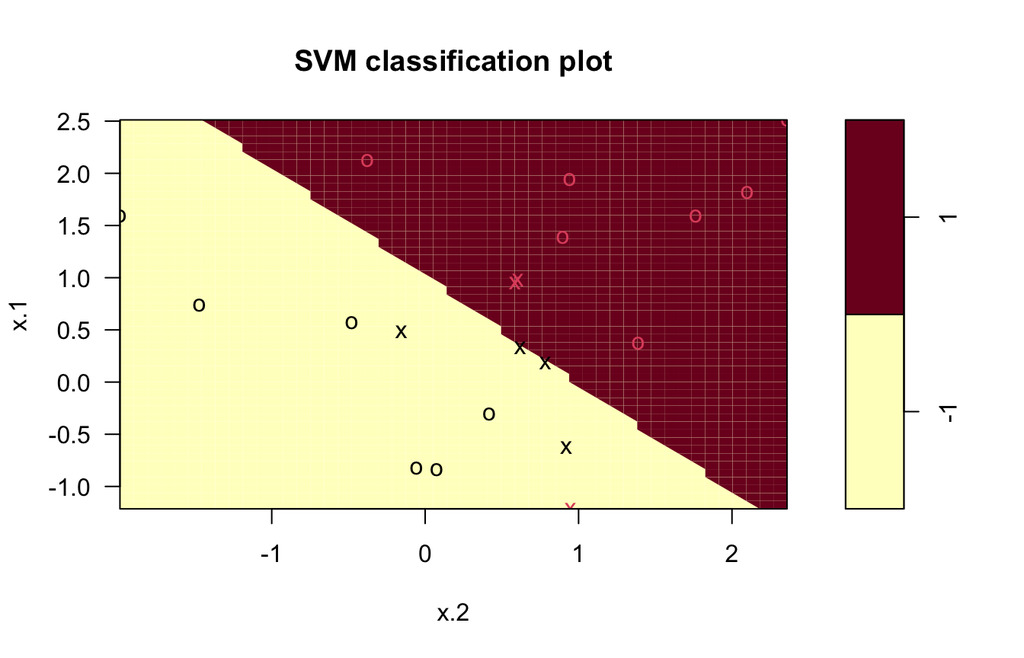

```r
svmfit = svm(y~.,data=dat,kernel="linear",cost=10,scale=FALSE)
plot(svmfit,dat)
```

The support vectors (data points) are on the margins or over the margins and are marked with an the “X” on this figure.

```r
## Index gives the observations that are support points.
svmfit$index
```

```
## [1]  1  2  5  7 14 16 17
```

```r
summary(svmfit)
```

```
##
## Call:
## svm(formula = y ~ ., data = dat, kernel = "linear", cost = 10, scale = FALSE)
##
##
## Parameters:
##    SVM-Type:  C-classification
##  SVM-Kernel:  linear
##        cost:  10
##
## Number of Support Vectors:  7
##
##  ( 4 3 )
##
##
## Number of Classes:  2
##
## Levels:
##  -1 1
```

Now let’s reduce the cost of being a support vector from 10 down to 0.01:

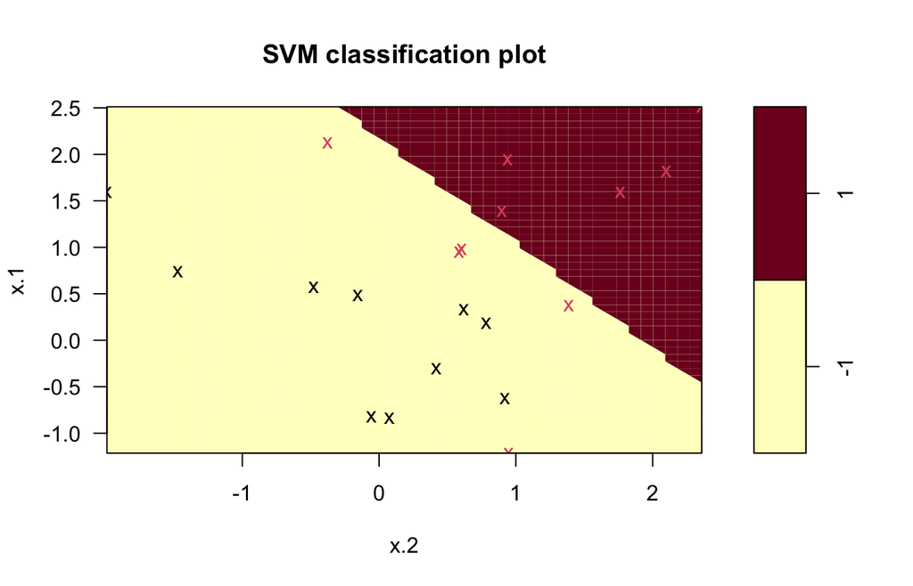

```r
svmfit = svm(y~.,data=dat,kernel="linear",cost=0.01,scale=FALSE)
plot(svmfit,dat)
```

```r
summary(svmfit)
```

```
##
## Call:
## svm(formula = y ~ ., data = dat, kernel = "linear", cost = 0.01,
##     scale = FALSE)
##
##
## Parameters:
##    SVM-Type:  C-classification
##  SVM-Kernel:  linear
##        cost:  0.01
##
## Number of Support Vectors:  20
##
##  ( 10 10 )
##
##
## Number of Classes:  2
##
## Levels:
##  -1 1
```

Now we’ll check this out for a number of costs and see which works best. For this we’ll use 10-fold cross validation (which is the default for the function below), which is why we set a seed. Note that the `tune` function is part of the `e1071` package that we are using to fit SVMs

```r
set.seed(1)
tune.out <- tune(svm, y~., data=dat, kernel="linear",
                 ranges=list(cost=c(0.001,0.01,0.1,1,5,10,100)))
summary(tune.out)
```

```
##
## Parameter tuning of 'svm':
##
## - sampling method: 10-fold cross validation
##
## - best parameters:
##  cost
##   0.1
##
## - best performance: 0.05
##
## - Detailed performance results:
##    cost error dispersion
## 1 1e-03  0.55  0.4377975
## 2 1e-02  0.55  0.4377975
## 3 1e-01  0.05  0.1581139
## 4 1e+00  0.15  0.2415229
## 5 5e+00  0.15  0.2415229
## 6 1e+01  0.15  0.2415229
## 7 1e+02  0.15  0.2415229
```

```r
bestmod = tune.out$best.model
summary(bestmod)
```

```
##
## Call:
## best.tune(METHOD = svm, train.x = y ~ ., data = dat, ranges = list(cost = c(0.001,
##     0.01, 0.1, 1, 5, 10, 100)), kernel = "linear")
##
##
## Parameters:
##    SVM-Type:  C-classification
##  SVM-Kernel:  linear
##        cost:  0.1
##
## Number of Support Vectors:  16
##
##  ( 8 8 )
##
##
## Number of Classes:  2
##
## Levels:
##  -1 1
```

```r
ypred = predict(bestmod,testdat)
ypred
```

```
##  1  2  3  4  5  6  7  8  9 10 11 12 13 14 15 16 17 18 19 20
##  1 -1  1 -1 -1 -1 -1  1 -1  1  1 -1  1 -1  1  1 -1 -1  1 -1
## Levels: -1 1
```

```r
table(ypred,testdat$y)
```

```
##
## ypred -1 1
##    -1  6 5
##    1   4 5
```

Now let’s look at some non-linear data.

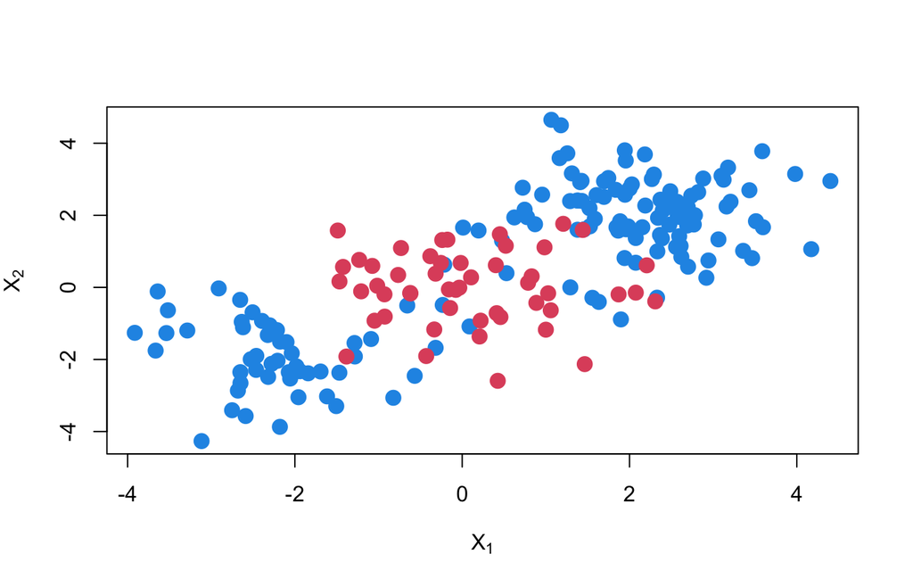

```r
set.seed(1)
x <- matrix(rnorm(200*2),ncol=2)
x[1:100,] = x[1:100,]+2
x[101:150,] = x[101:150,]-2
y <- c(rep(-1,150),rep(1,50))
dat <- data.frame(x=x,y=as.factor(y))
plot(x,col=(3-y),xlab=expression(X[1]),ylab=expression(X[2]), pch = 19, cex = 1.5)
```

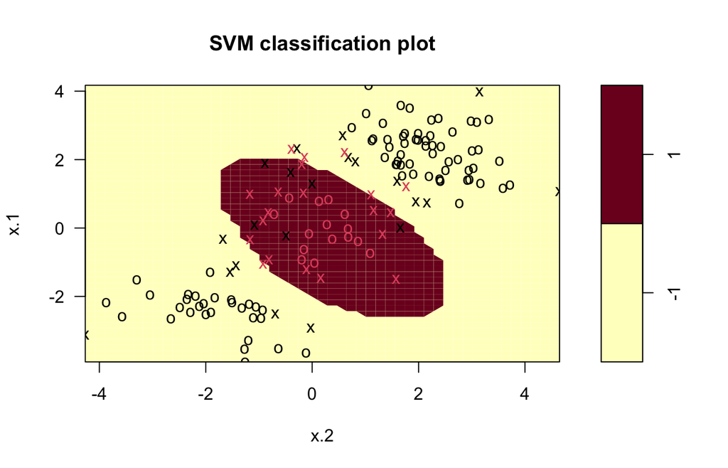

```r
set.seed(735)
train_index <- createDataPartition(dat$y, p = 0.7, list = FALSE)
train <- dat[train_index, ]
test  <- dat[-train_index, ]

svmfit = svm(y~., data=train, kernel="radial", cost=1, gamma=1)
par(mfrow=c(1,2))
plot(svmfit,train)
```

```r
summary(svmfit)
```

```
##
## Call:
## svm(formula = y ~ ., data = train, kernel = "radial", cost = 1, gamma = 1)
##
##
## Parameters:
##    SVM-Type:  C-classification
##  SVM-Kernel:  radial
##        cost:  1
##
## Number of Support Vectors:  41
##
##  ( 21 20 )
##
##
## Number of Classes:  2
##
## Levels:
##  -1 1
```

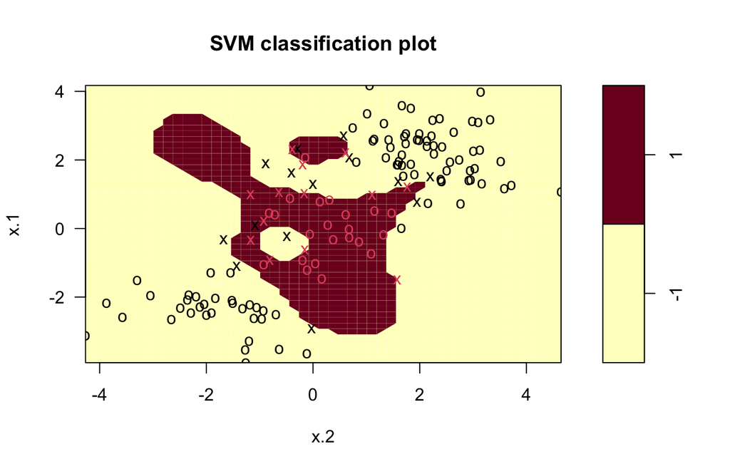

```r
svmfit2 = svm(y~.,data=train,kernel="radial",cost=1e4,gamma=1)
plot(svmfit2,train)
```

```r
tune.out <- tune(svm, y~., data = train, kernel="radial",
                 ranges=list(
                   cost=c(0.001,0.01,0.1,1,5,10,100),
                   gamma=c(0.5,1,2,3,4)
                   ))
summary(tune.out)$performances %>% arrange(error) %>% filter(row_number()<10) %>% kbl2(digits = 3)
```

| cost | gamma | error | dispersion |
| --- | --- | --- | --- |
| 1 | 0.5 | 0.086 | 0.056 |
| 5 | 0.5 | 0.093 | 0.059 |
| 10 | 0.5 | 0.100 | 0.069 |
| 100 | 0.5 | 0.100 | 0.069 |
| 1 | 1.0 | 0.100 | 0.069 |
| 5 | 1.0 | 0.100 | 0.069 |
| 10 | 1.0 | 0.100 | 0.069 |
| 100 | 1.0 | 0.100 | 0.069 |
| 5 | 2.0 | 0.100 | 0.069 |

```r
table(true=test$y,pred=predict(tune.out$best.model,newdata=test))%>% kbl2(digits = 3)
```

|  | -1 | 1 |
| --- | --- | --- |
| -1 | 39 | 6 |
| 1 | 5 | 10 |

Now we’ll fit an SVM to some multiclass data.

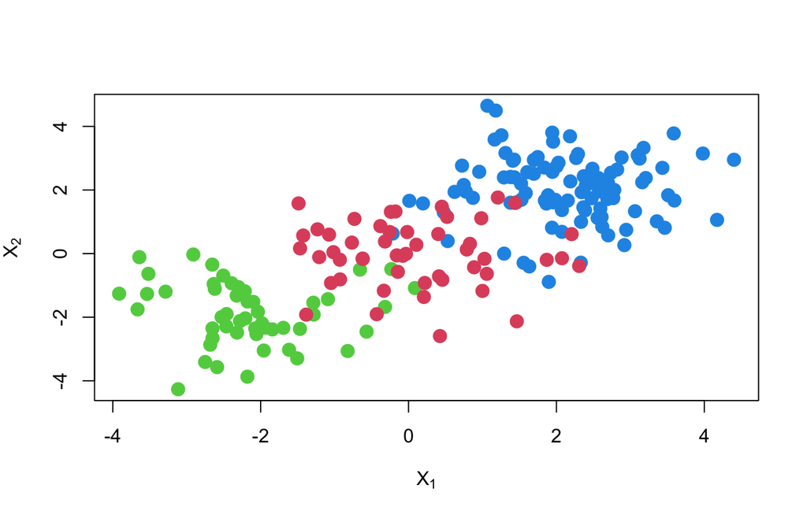

```r
set.seed(1)
y[101:150] <- 0
par(mfrow=c(1,1))
plot(x,col=(3-y),xlab=expression(X[1]),ylab=expression(X[2]), pch = 19, cex = 1.5)
```

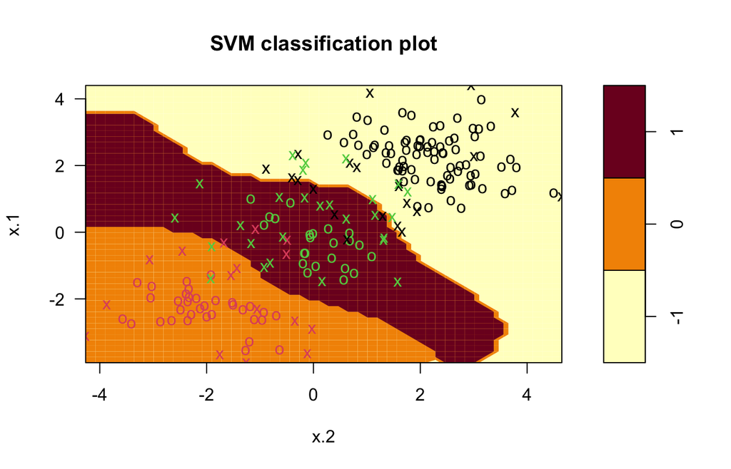

```r
dat <- data.frame(x=x,y=as.factor(y)) #the as.factor is important so we don't do regression.
svmfit = svm(y~.,data=dat,kernel="radial",cost=10,gamma=1)
plot(svmfit,dat)
```

# Support Vector Machines for Regression

We begin with the Communities and Crime dataset.

## Read in the data

```r
# Load Communities and Crime data
crime <- readRDS("community_crime.RDS")

# Split into training and test sets
set.seed(735)
train_index <- createDataPartition(crime$ViolentCrime, p = 0.67, list = FALSE)
train <- crime[train_index, ]
test  <- crime[-train_index, ]
```

## Scale predictors (SVMs are sensitive to scale)

**Preprocessing Recipe** Before commensing with the CV, we’re going to create some functions to help us scale/center predictors. We will pass this function onto `train` below.

Recipes ensure that preprocessing steps (like centering and scaling) are applied only within training folds during CV, preventing data leakage.

Without recipes, scaling parameters are estimated from the full training set, potentially giving the model unfair access to information about the validation fold.

```r
crime_recipe <- recipe(ViolentCrime ~ ., data = train) %>%
  step_center(all_predictors()) %>%
  step_scale(all_predictors())

crime_recipe
```

## Fit SVM Regression Model (Radial Kernel)

$$K(u,v) = \exp(|u -
v|^2/\sigma)$$

Were going to use the `train` function in `caret` to select our tuning parameters. This uses the `ksvm` functon in the `kernlab` package, which has a lot more options than `e1071::svm`.

By default, `Caret` automatically estimates `sigma` parameter from your predictors using the `sigest()` function. This happens once before tuning, so only C (`cost`) is actually tuned. If we wanted to tune `sigma` we could give the `train` a grid of sigma and cost parameters to test.

```r
ctrl <- trainControl(
  method = "cv",
  number = 10,
  savePredictions = "final",
  summaryFunction = defaultSummary
)

set.seed(735)
svm_fit <- train(
  crime_recipe,
  data = train,
  method = "svmRadial",
  trControl = ctrl,
  tuneLength = 8,   # tries 8 different C values
  metric = "RMSE"
)


svm_fit
```

```
## Support Vector Machines with Radial Basis Function Kernel
##
## 1338 samples
##  100 predictor
##
## Recipe steps: center, scale
## Resampling: Cross-Validated (10 fold)
## Summary of sample sizes: 1205, 1203, 1204, 1205, 1205, 1204, ...
## Resampling results across tuning parameters:
##
##   C      RMSE       Rsquared   MAE
##    0.25  0.1499789  0.6230002  0.09682773
##    0.50  0.1452363  0.6337364  0.09449175
##    1.00  0.1425656  0.6390059  0.09327681
##    2.00  0.1425129  0.6350445  0.09487217
##    4.00  0.1448948  0.6222747  0.09807809
##    8.00  0.1503271  0.5957196  0.10357550
##   16.00  0.1580293  0.5601155  0.11076268
##   32.00  0.1646085  0.5326833  0.11683896
##
## Tuning parameter 'sigma' was held constant at a value of 0.008319284
## RMSE was used to select the optimal model using the smallest value.
## The final values used for the model were sigma = 0.008319284 and C = 2.
```

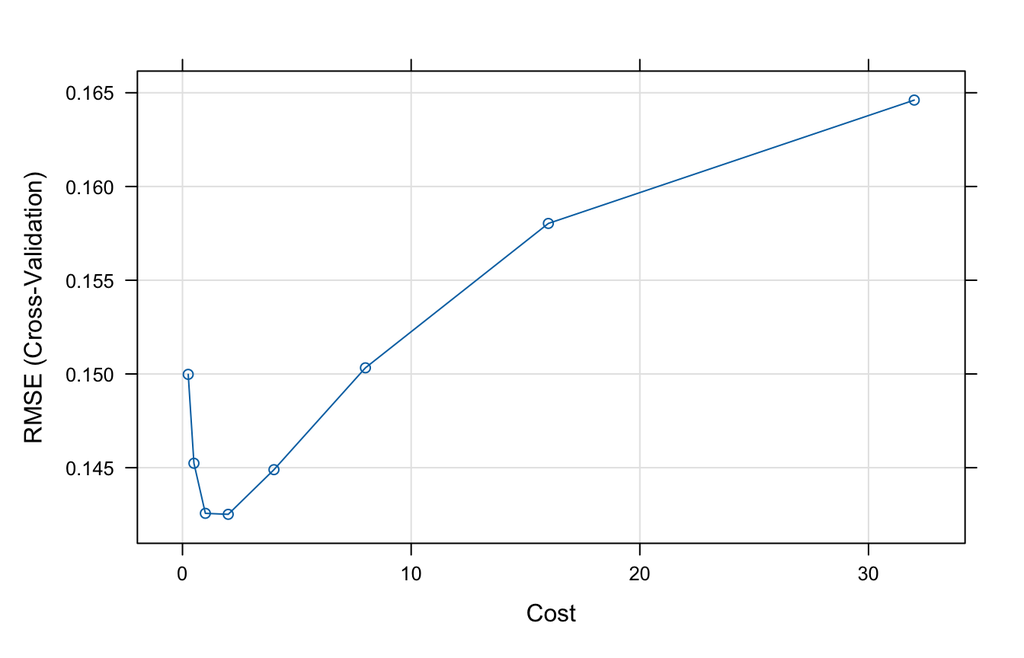

```r
plot(svm_fit)
```

## Evaluate on the Test Set

Now we’ll use the fitted model to predict Violent Crime in the test set and calculate RMSE and (R^2).

```r
pred_test <- predict(svm_fit, newdata = test)
RMSE_val <- sqrt(mean((pred_test - test$ViolentCrime)^2))
R2_val   <- cor(pred_test, test$ViolentCrime)^2

tibble(
  Metric = c("Test RMSE", "Test R²"),
  Value = c(RMSE_val, R2_val)
) %>% kable(digits = 4)
```

| Metric | Value |
| --- | --- |
| Test RMSE | 0.1330 |
| Test R² | 0.6709 |

⸻

## Predicted vs Observed Plot

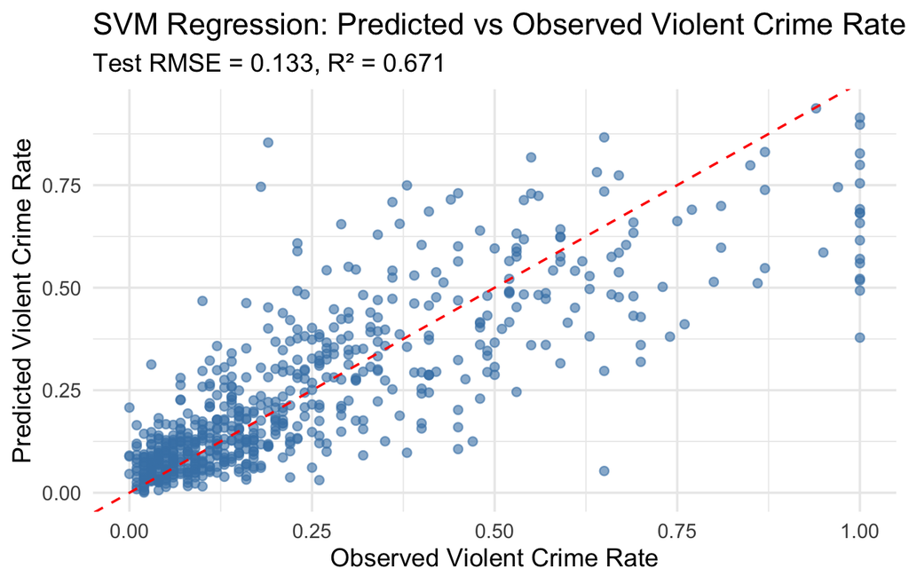

```r
ggplot(data.frame(Observed = test$ViolentCrime, Predicted = pred_test),
       aes(x = Observed, y = Predicted)) +
  geom_point(alpha = 0.6, color = "steelblue") +
  geom_abline(slope = 1, intercept = 0, color = "red", linetype = "dashed") +
  labs(
    title = "SVM Regression: Predicted vs Observed Violent Crime Rate",
    subtitle = paste0("Test RMSE = ", round(RMSE_val, 3),
                      ", R² = ", round(R2_val, 3)),
    x = "Observed Violent Crime Rate",
    y = "Predicted Violent Crime Rate"
  ) +
  theme_minimal(base_size = 14)
```

⸻

## Variable Importance

Variable importance is estimated based on the SVM model weights in the kernel space.

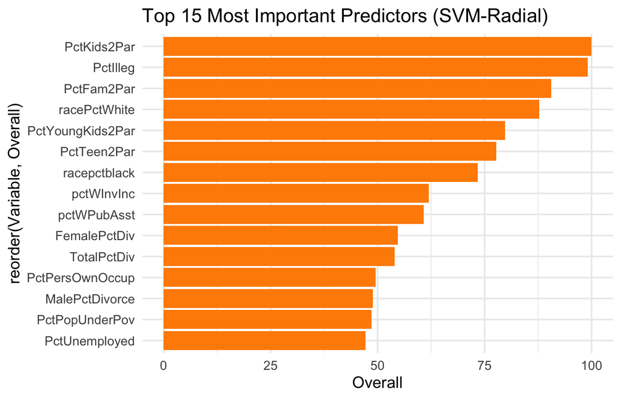

```r
varImp(svm_fit)$importance %>%
  as.data.frame() %>%
  rownames_to_column("Variable") %>%
  arrange(desc(Overall)) %>%
  head(15) %>%
  ggplot(aes(x = reorder(Variable, Overall), y = Overall)) +
  geom_col(fill = "darkorange") +
  coord_flip() +
  labs(title = "Top 15 Most Important Predictors (SVM-Radial)") +
  theme_minimal(base_size = 13)
```

## Compare with Random Forest

```r
set.seed(123)

# Define training control for 10-fold CV
ctrl <- trainControl(method = "cv", number = 10)

# Train random forest model with CV to tune mtry
rf_caret <- train(ViolentCrime ~ .,
                  data = train,
                  method = "rf",
                  metric = "RMSE",
                  trControl = ctrl,
                  tuneGrid = data.frame(mtry = 1:20)) # grid of mtry values

pred_test_rf <- predict(rf_caret$finalModel, newdata = test)
RMSE_val_rf <- sqrt(mean((pred_test_rf - test$ViolentCrime)^2))
R2_val_rf   <- cor(pred_test_rf, test$ViolentCrime)^2

tibble(
  Metric = c("SVM (Radial)", "Random Forests"),
  "Test RMSE" = c(RMSE_val,RMSE_val_rf),
   "Test R²" = c(R2_val, R2_val_rf)
) %>% kable(digits = 4)
```

| Metric | Test RMSE | Test R² |
| --- | --- | --- |
| SVM (Radial) | 0.1330 | 0.6709 |
| Random Forests | 0.1293 | 0.6924 |

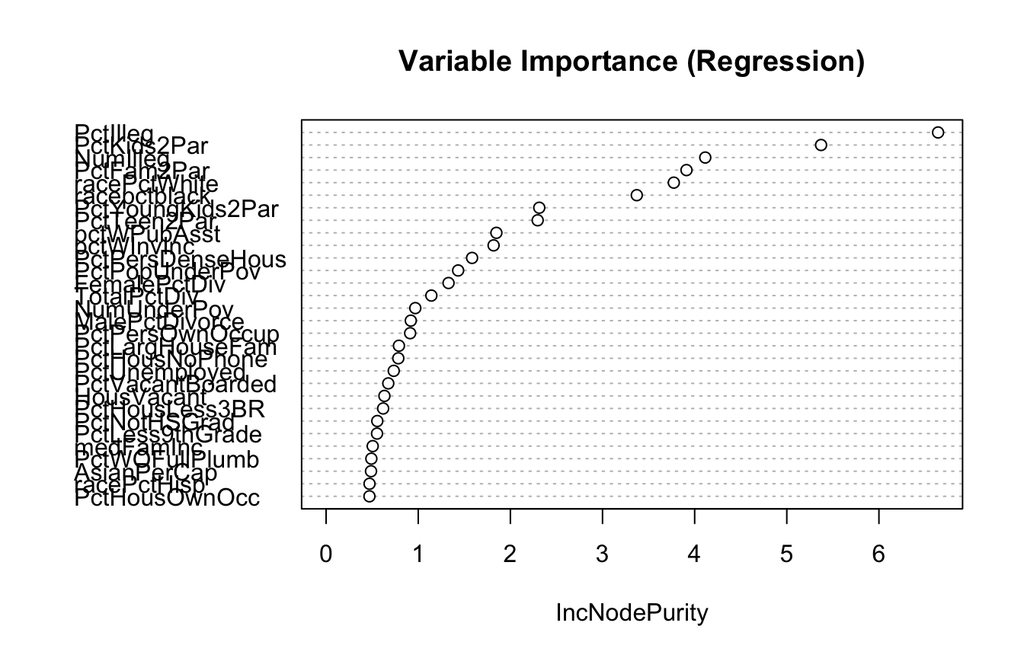

```r
rf_reg <- rf_caret$finalModel
varImpPlot(rf_reg, main = "Variable Importance (Regression)")
```

# SVM for Classification

We now turn to the Pima Diabetes dataset.

```r
data(PimaIndiansDiabetes)
df <- PimaIndiansDiabetes
glimpse(df)
```

```
## Rows: 768
## Columns: 9
## $ pregnant <dbl> 6, 1, 8, 1, 0, 5, 3, 10, 2, 8, 4, 10, 10, 1, 5, 7, 0, 7, 1, 1…
## $ glucose  <dbl> 148, 85, 183, 89, 137, 116, 78, 115, 197, 125, 110, 168, 139,…
## $ pressure <dbl> 72, 66, 64, 66, 40, 74, 50, 0, 70, 96, 92, 74, 80, 60, 72, 0,…
## $ triceps  <dbl> 35, 29, 0, 23, 35, 0, 32, 0, 45, 0, 0, 0, 0, 23, 19, 0, 47, 0…
## $ insulin  <dbl> 0, 0, 0, 94, 168, 0, 88, 0, 543, 0, 0, 0, 0, 846, 175, 0, 230…
## $ mass     <dbl> 33.6, 26.6, 23.3, 28.1, 43.1, 25.6, 31.0, 35.3, 30.5, 0.0, 37…
## $ pedigree <dbl> 0.627, 0.351, 0.672, 0.167, 2.288, 0.201, 0.248, 0.134, 0.158…
## $ age      <dbl> 50, 31, 32, 21, 33, 30, 26, 29, 53, 54, 30, 34, 57, 59, 51, 3…
## $ diabetes <fct> pos, neg, pos, neg, pos, neg, pos, neg, pos, pos, neg, pos, n…
```

```r
# Outcome should be a factor with "neg" as reference
df$diabetes <- factor(df$diabetes, levels = c("neg", "pos"))

set.seed(735)
train_index <- createDataPartition(df$diabetes, p = 0.8, list = FALSE)
train <- df[train_index, ]
test  <- df[-train_index, ]

svm_recipe <- recipe(diabetes ~ ., data = train) %>%
  step_center(all_predictors()) %>%
  step_scale(all_predictors())
```

## Cross-validation to select `cost` with `sigma`

```r
ctrl <- trainControl(
  method = "cv",
  number = 10,
  classProbs = TRUE,
  summaryFunction = twoClassSummary,  # computes ROC, Sens, Spec
  savePredictions = "final"
)

# Define grid for both sigma and C
svm_grid <- expand.grid(
  sigma = 2^seq(-10, -3, length.out = 5),
  C = 2^seq(-2, 4, length.out = 6)
)


set.seed(123)

svm_fit <- train(
  svm_recipe,
  data = train,
  method = "svmRadial",
  tuneGrid = svm_grid,
  trControl = ctrl,
  metric = "ROC"
)

svm_fit$results %>% arrange(-ROC) %>% filter(row_number()<8) %>% kbl2(digits = 4)
```

| sigma | C | ROC | Sens | Spec | ROCSD | SensSD | SpecSD |
| --- | --- | --- | --- | --- | --- | --- | --- |
| 0.0372 | 0.5743 | 0.8333 | 0.8700 | 0.5684 | 0.0422 | 0.0654 | 0.1267 |
| 0.0372 | 0.2500 | 0.8329 | 0.8600 | 0.5920 | 0.0438 | 0.0615 | 0.1415 |
| 0.0372 | 1.3195 | 0.8317 | 0.8800 | 0.5589 | 0.0442 | 0.0695 | 0.1155 |
| 0.0110 | 3.0314 | 0.8316 | 0.8800 | 0.5539 | 0.0435 | 0.0537 | 0.1314 |
| 0.0110 | 6.9644 | 0.8316 | 0.8925 | 0.5260 | 0.0442 | 0.0566 | 0.1183 |
| 0.0033 | 6.9644 | 0.8300 | 0.8800 | 0.5446 | 0.0436 | 0.0453 | 0.1302 |
| 0.0110 | 1.3195 | 0.8296 | 0.8775 | 0.5541 | 0.0438 | 0.0520 | 0.1243 |

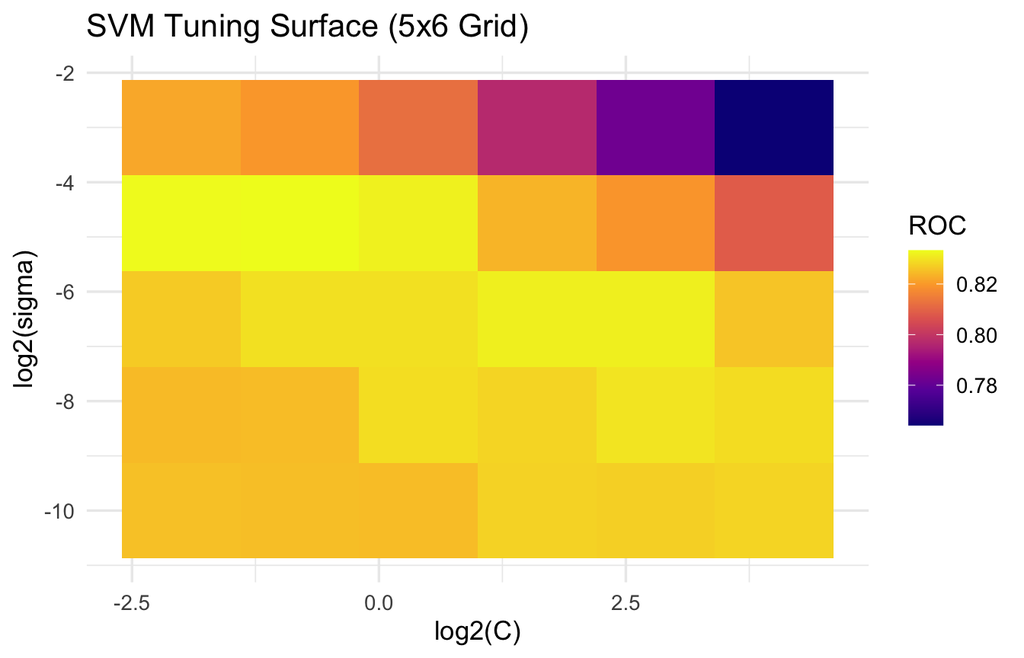

```r
ggplot(svm_fit$results, aes(x = log2(C), y = log2(sigma), fill = ROC)) +
  geom_tile() +
  scale_fill_viridis_c(option = "C") +
  labs(
    title = "SVM Tuning Surface (5x6 Grid)",
    x = "log2(C)",
    y = "log2(sigma)"
  ) +
  theme_minimal(base_size = 13)
```

## Variable Importance for Final Model

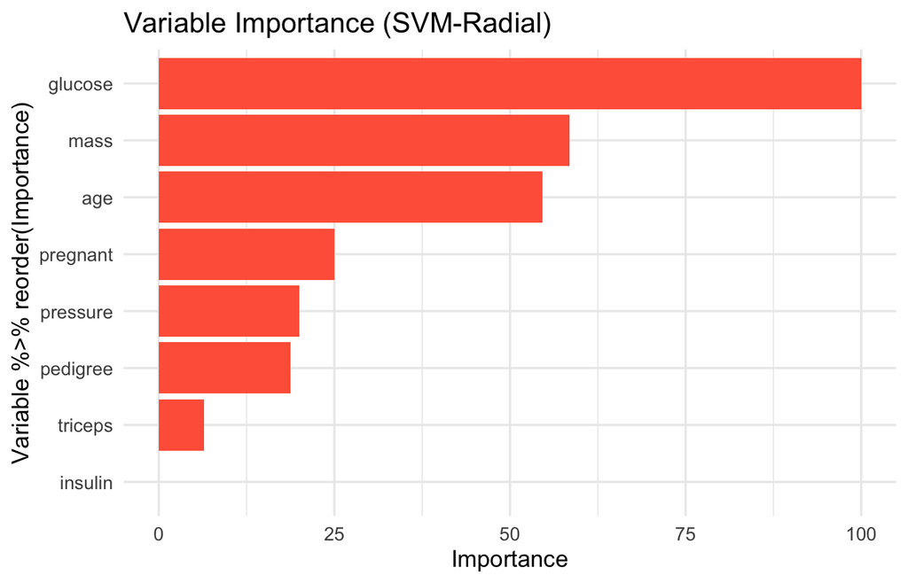

```r
varImp(svm_fit)$importance %>%
  as.data.frame() %>%
  rownames_to_column("Variable") %>%
  select(Variable,neg) %>% rename(Importance = neg) %>%
  ggplot(aes(x = Variable %>% reorder(Importance), y = Importance)) +
  geom_col(fill = "tomato") +
  coord_flip() +
  labs(title = "Variable Importance (SVM-Radial)") +
  theme_minimal(base_size = 13)
```

## Partial Dependence Plots (Classification)

[figure not shown]

```r
p3 <- partial(svm_fit, pred.var = "glucose", train = train, which.class = "pos")
autoplot(p3, main = "PDP: Glucose (Diabetes Probability)")
```

[figure not shown]

```r
p4 <- partial(svm_fit, pred.var = "age", train = train, which.class = "pos")
autoplot(p4, main = "PDP: Age (Diabetes Probability)")
```

## Evaluate on Test Set

```r
pred_probs <- predict(svm_fit, newdata = test, type = "prob")
pred_class <- predict(svm_fit, newdata = test)

roc_obj <- roc(test$diabetes, pred_probs$pos, levels = c("neg", "pos"))
auc_val <- auc(roc_obj)

cm <- confusionMatrix(pred_class, test$diabetes, positive = "pos")

tibble(
  Metric = c("AUC", "Accuracy", "Sensitivity", "Specificity"),
  Value = c(
    auc_val,
    cm$overall["Accuracy"],
    cm$byClass["Sensitivity"],
    cm$byClass["Specificity"]
  )
)
```

| Metric | Value |
| --- | --- |
| AUC | 0.8616981 |
| Accuracy | 0.7647059 |
| Sensitivity | 0.5849057 |
| Specificity | 0.8600000 |

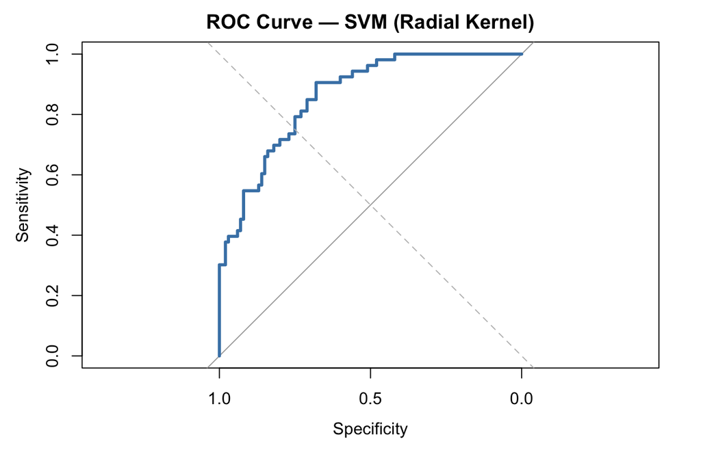

```r
plot(roc_obj, col = "steelblue", lwd = 3, main = "ROC Curve — SVM (Radial Kernel)")
abline(a = 0, b = 1, lty = 2, col = "gray")
```

## Comparison to Logistic Regression and Random Forests

Fit with logistic regression:

```r
set.seed(735)
fit_logit <- train(
  svm_recipe,
  data = train,
  method = "glm",
  family = binomial,
  trControl = ctrl,
  metric = "ROC"
)

summary(fit_logit$finalModel)
```

```
##
## Call:
## NULL
##
## Coefficients:
##             Estimate Std. Error z value Pr(>|z|)
## (Intercept) -0.86527    0.10780  -8.027  1.0e-15 ***
## pregnant     0.31856    0.12113   2.630  0.00854 **
## glucose      1.17722    0.13306   8.847  < 2e-16 ***
## pressure    -0.22530    0.11328  -1.989  0.04673 *
## triceps      0.05832    0.12303   0.474  0.63545
## insulin     -0.14160    0.11420  -1.240  0.21501
## mass         0.69702    0.13270   5.253  1.5e-07 ***
## pedigree     0.26301    0.10638   2.472  0.01342 *
## age          0.16451    0.12493   1.317  0.18788
## ---
## Signif. codes:  0 '***' 0.001 '**' 0.01 '*' 0.05 '.' 0.1 ' ' 1
##
## (Dispersion parameter for binomial family taken to be 1)
##
##     Null deviance: 796.05  on 614  degrees of freedom
## Residual deviance: 584.55  on 606  degrees of freedom
## AIC: 602.55
##
## Number of Fisher Scoring iterations: 5
```

Fit with Random Forest:

```r
set.seed(735)
fit_rf <- train(
  svm_recipe,
  data = train,
  method = "rf",
  trControl = ctrl,
  tuneLength = 5,
  metric = "ROC"
)

fit_rf
```

```
## Random Forest
##
## 615 samples
##   8 predictor
##   2 classes: 'neg', 'pos'
##
## Recipe steps: center, scale
## Resampling: Cross-Validated (10 fold)
## Summary of sample sizes: 554, 553, 553, 554, 554, 554, ...
## Resampling results across tuning parameters:
##
##   mtry  ROC        Sens    Spec
##   2     0.8121050  0.8350  0.5887446
##   3     0.8148539  0.8325  0.6032468
##   5     0.8073945  0.8300  0.5796537
##   6     0.8057657  0.8300  0.5844156
##   8     0.8079383  0.8125  0.5939394
##
## ROC was used to select the optimal model using the largest value.
## The final value used for the model was mtry = 3.
```

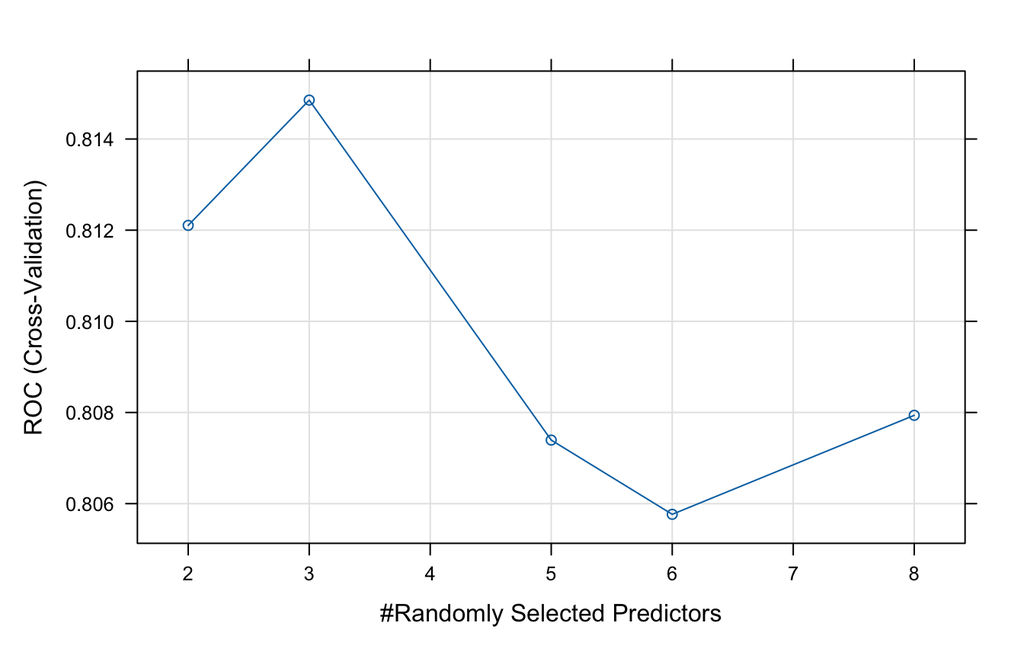

```r
plot(fit_rf)
```

### Compare performance using CV

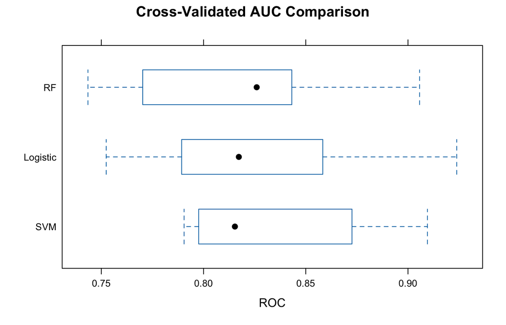

```r
res <- resamples(list(
  Logistic = fit_logit,
  SVM = svm_fit,
  RF = fit_rf
))

# Boxplot comparison of AUC, Sens, Spec
bwplot(res, metric = "ROC", main = "Cross-Validated AUC Comparison")
```

### Compare performance using the Test Set

```r
predict_and_eval <- function(model, name) {
  prob <- predict(model, newdata = test, type = "prob")[, "pos"]
  pred <- predict(model, newdata = test)
  roc_obj <- roc(test$diabetes, prob, levels = c("neg", "pos"))
  auc_val <- auc(roc_obj)
  cm <- confusionMatrix(pred, test$diabetes, positive = "pos")
  tibble(
    Model = name,
    AUC = auc_val,
    Accuracy = cm$overall["Accuracy"],
    Sensitivity = cm$byClass["Sensitivity"],
    Specificity = cm$byClass["Specificity"]
  )
}

logit_res <- predict_and_eval(fit_logit, "Logistic Regression")
svm_res <- predict_and_eval(svm_fit, "SVM (RBF)")
rf_res <- predict_and_eval(fit_rf, "Random Forest")


rbind(logit_res, svm_res, rf_res) %>%
  mutate(across(-Model, round, 3)) %>%
  knitr::kable(caption = "Test Set Performance Comparison")
```

Test Set Performance Comparison

| Model | AUC | Accuracy | Sensitivity | Specificity |
| --- | --- | --- | --- | --- |
| Logistic Regression | 0.855 | 0.778 | 0.623 | 0.86 |
| SVM (RBF) | 0.862 | 0.765 | 0.585 | 0.86 |
| Random Forest | 0.865 | 0.797 | 0.660 | 0.87 |

# Discussion

**Model Strengths Limitations**

- **Logistic Regression:** Simple, interpretable, fast. Misses non-linearities and interactions.
- **SVM (RBF):** Captures nonlinear boundaries, good for medium data (*not too small* and *not too large*). Less interpretable, sensitive to tuning.
- **Random Forest:** Captures interactions, robust, easy variable importance. Can overfit, less interpretable.

Interpretation:

- SVM and Random Forest often outperform Logistic Regression when nonlinear relationships exist.
- Logistic Regression remains valuable for interpretability.
- Cross-validation ensures fair, unbiased comparison.